# CSSS 508, Week 10

Rebecca Ferrell  
June 1, 2016

### Topics

- Scraping the web with `rvest`
- Mining text with `tm`
- What next?

## Web scraping with rvest

### Wait, isn't that Argus Filch?

[figure not shown]

### Game of Thrones x Harry Potter

We'll use the package `rvest` (“harvest”) to grab [IMDb](http://www.imdb.com) casts for Game of Thrones and Harry Potter to identify all overlapping actors.

```r
# install.packages("rvest")
library(rvest)
```

First, try out [SelectorGadget](https://cran.r-project.org/web/packages/rvest/vignettes/selectorgadget.html).

```r
# pull full Game of Thrones cast page
got_page <- read_html("http://www.imdb.com/title/tt0944947/fullcredits")
got_cast_raw <- got_page %>%
    html_nodes(".itemprop .itemprop , .character div") %>%
    html_text()
```

### Cleaning up the Game of Thrones cast

```r
head(got_cast_raw)
```

```
[1] "Peter Dinklage"
[2] "\n         Tyrion Lannister\n                  (56 episodes, 2011-2016)\n              "
[3] "Lena Headey"
[4] "\n         Cersei Lannister\n                  (50 episodes, 2011-2016)\n              "
[5] "Kit Harington"
[6] "\n         Jon Snow\n                  (47 episodes, 2011-2016)\n              "
```

Pattern appears to be: [actor name], [messy character info], repeat.

### Cleaning up the Game of Thrones cast

Make a data frame:

```r
got_cast_df <- data.frame(matrix(got_cast_raw, ncol = 2, byrow = TRUE), stringsAsFactors = FALSE)
colnames(got_cast_df) <- c("Actor", "char_info")
head(got_cast_df, 3)
```

```
           Actor
1 Peter Dinklage
2    Lena Headey
3  Kit Harington
                                                                                char_info
1 \n         Tyrion Lannister\n                  (56 episodes, 2011-2016)\n
2 \n         Cersei Lannister\n                  (50 episodes, 2011-2016)\n
3         \n         Jon Snow\n                  (47 episodes, 2011-2016)\n
```

### Clean up the character column

We want to trim initial whitespace, extract the character, and move the episode count to a new column.

```r
library(stringr); library(dplyr)
got_cast <- got_cast_df %>%
    mutate(char_info = str_trim(char_info),
           GoT_character = str_trim(str_extract(char_info, "^.*\\n")),
           Episodes = as.numeric(str_extract(str_extract(char_info, "[0-9]* episode"), "[0-9]*"))) %>%
    select(-char_info)
```

### Scraping Harry Potter actors

We'll want to loop over all eight films to do this!

```r
HP_URLs <- c("http://www.imdb.com/title/tt0241527/fullcredits", "http://www.imdb.com/title/tt0295297/fullcredits", "http://www.imdb.com/title/tt0304141/fullcredits", "http://www.imdb.com/title/tt0330373/fullcredits", "http://www.imdb.com/title/tt0373889/fullcredits", "http://www.imdb.com/title/tt0417741/fullcredits", "http://www.imdb.com/title/tt0926084/fullcredits", "http://www.imdb.com/title/tt1201607/fullcredits")
```

### Harry Potter scraping

Looping game plan:

1. Create a list with a spot for each film
2. Scrape the cast into the spot for each film
3. Reshape the character vector into a matrix
4. Combine the casts of all the films
5. Remove whitespace, etc.

```r
HP_cast_list <- vector("list", length(HP_URLs))
```

### Looping

Consolidate the work done for GoT into a loop for HP:

```r
for(i in seq_along(HP_URLs)) {
    HP_cast_list[[i]] <- read_html(HP_URLs[i]) %>%
        html_nodes(".itemprop .itemprop , .character div") %>%
        html_text() %>%
        matrix(ncol = 2, byrow = TRUE) %>%
        data.frame(stringsAsFactors = FALSE)
    colnames(HP_cast_list[[i]]) <- c("Actor", "HP_character")
}
HP_cast <- bind_rows(HP_cast_list, .id = "HP_film") %>%
    mutate_each(funs(str_trim))
```

### Who was in both?

```r
both_GoT_HP <- HP_cast %>%
    inner_join(got_cast, by = "Actor") %>%
    arrange(desc(Episodes), Actor)
```

[figure not shown]

### Other ways of getting data off the web

Specialized packages for specific services:

- `twitteR` (Twitter REST API), `streamR` (Twitter streaming API), `Rfacebook`
  - Require you get a key to run queries – store in separate file and pull in, do not hardcode/share with others!
  - Rate limiting can be challenge, use `Sys.sleep(seconds)` if needed to slow code down

General API access:

- `httr` for HTTP requests and responses
- `jsonlite` for parsing JSON, `XML` for XML

Many tutorials just a Google search away!

## Text mining with tm

### Text mining terminology

- `tm`: R package for performing text mining
- Term: word
- Document: collection of terms
- Corpus: a collection of documents (plural: corpora)
- Dictionary: set of relevant terms

### My first corpus

We can make a toy corpus manually by creating a character vector, running `VectorSource` on it to read it in, and then `VCorpus` to corpus-ify:

```r
library(tm)
UW_tweets <- c("Remembering and honoring those who made the ultimate sacrifice while serving our country. #MemorialDay2016", "VIDEO: This spring @UW students taught literacy arts to #Colville Reservation students. Check out book they made!", "Enjoy the long weekend, Huskies! And to those studying for finals: Good luck and hang in there!", ".@UWBuerk & @UWFosterSchool–hosted biz plan competition awards $85,000 to students for new ventures. http://ow.ly/3PtI300F87Y  #UWinnovates")
toy_corpus <- VCorpus(VectorSource(UW_tweets))
```

### Accessing corpus entries

A corpus is just a fancy list of documents, and you can access a document as a list entry:

```r
toy_corpus[[3]]
```

```
<<PlainTextDocument>>
Metadata:  7
Content:  chars: 95
```

```r
as.character(toy_corpus[[3]])
```

```
[1] "Enjoy the long weekend, Huskies! And to those studying for finals: Good luck and hang in there!"
```

### Text files as documents

You will more likely be making corpora from sources like Twitter or reading in data from text files.

We'll import a sample of emails from the [Enron corpus](http://bailando.sims.berkeley.edu/enron_email.html) assembled by UC Berkeley students. First, let's download a ZIP file with the text files and unzip it.

```r
download.file("https://www.dropbox.com/s/qrd1j44qnlzg68a/enron_sample_emails.zip?dl=1", destfile = "enron_emails.zip", mode = "wb")
unzip("enron_emails.zip", exdir = "enron_emails")
```

```r
length(list.files("enron_emails/enron_sample_emails"))
```

```
[1] 100
```

### Reading in text files

Make a corpus where each document is an email in the Enron subsample:

```r
enron_corpus <- VCorpus(DirSource(directory = "enron_emails/enron_sample_emails", mode = "text"))
as.character(enron_corpus[[3]])
```

```
 [1] "Message-ID: <26658543.1075843310470.JavaMail.evans@thyme>"
 [2] "Date: Fri, 22 Dec 2000 04:00:00 -0800 (PST)"
 [3] "From: sarah.novosel@enron.com"
 [4] "To: susan.mara@enron.com"
 [5] "Subject: Re: Wolak report"
 [6] "Cc: donna.fulton@enron.com, jeff.dasovich@enron.com"
 [7] "Mime-Version: 1.0"
 [8] "Content-Type: text/plain; charset=us-ascii"
 [9] "Content-Transfer-Encoding: 7bit"
[10] "Bcc: donna.fulton@enron.com, jeff.dasovich@enron.com"
[11] "X-From: Sarah Novosel"
[12] "X-To: Susan J Mara"
[13] "X-cc: Donna Fulton, Jeff Dasovich"
[14] "X-bcc: "
[15] "X-Folder: \\Jeff_Dasovich_June2001\\Notes Folders\\All documents"
```

[output cut: 29 more lines]

### Transformations (maps)

Let's change to lowercase, remove “stopwords” and header terms, remove punctuation, numbers, and whitespace, and “stem” the words:

```r
# install.packages("SnowballC") # may solve errors
enron_stripped <- enron_corpus %>%
    tm_map(content_transformer(str_to_lower)) %>%
    tm_map(removeWords, stopwords("english")) %>%
    tm_map(removeWords, c("javamail.evans@thyme", "message-id", "date", "subject", "mime-version", "content-type", "text/plain", "charset=us-ascii", "content-transfer-encoding", "x-", "x-cc", "x-bcc", "x-folder", "x-origin", "x-filename")) %>%
    tm_map(removePunctuation) %>%
    tm_map(removeNumbers) %>%
    tm_map(stripWhitespace) %>%
    tm_map(stemDocument)
```

### Word clouds

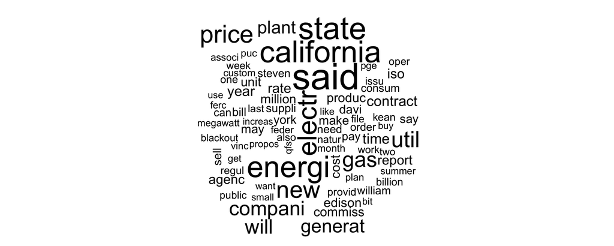

```r
library(wordcloud)
wordcloud(enron_stripped, min.freq = 2, max.words = 80)
```

### Filtering to emails with California

We'll write a function that takes the content of the documents and looks for any instance of `"california"`, then use it with `tm_filter`:

```r
doc_word_search <- function(x, pattern) {
    any(str_detect(content(x), pattern = pattern))
}
cali_emails <- enron_stripped %>%
    tm_filter(doc_word_search, pattern = "california")
length(cali_emails)
```

```
[1] 14
```

### Term-Document Matrices

We can look for patterns across the documents by constructing a `TermDocumentMatrix`:

```r
enron_tdm <- TermDocumentMatrix(enron_stripped)
str(enron_tdm)
```

```
List of 6
 $ i       : int [1:17721] 2 9 12 15 17 19 24 27 30 34 ...
 $ j       : int [1:17721] 1 1 1 1 1 1 1 1 1 1 ...
 $ v       : num [1:17721] 4 1 1 1 1 2 1 1 2 4 ...
 $ nrow    : int 5061
 $ ncol    : int 100
 $ dimnames:List of 2
  ..$ Terms: chr [1:5061] "abat" "abil" "abl" "abnorm" ...
  ..$ Docs : chr [1:100] "114495.txt" "115323.txt" "118675.txt" "119214.txt" ...
 - attr(*, "class")= chr [1:2] "TermDocumentMatrix" "simple_triplet_matrix"
 - attr(*, "weighting")= chr [1:2] "term frequency" "tf"
```

### What does the matrix look like?

Too big to view at once, but we can look at snippets with `inspect`:

```r
inspect(enron_tdm[1:5, 1:5])
```

```
<<TermDocumentMatrix (terms: 5, documents: 5)>>
Non-/sparse entries: 2/23
Sparsity           : 92%
Maximal term length: 7
Weighting          : term frequency (tf)

         Docs
Terms     114495.txt 115323.txt 118675.txt 119214.txt 12030.txt
  abat             0          0          0          0         0
  abil             4          0          0          0         0
  abl              0          0          0          0         1
  abnorm           0          0          0          0         0
  abolish          0          0          0          0         0
```

### Removing sparse words

We could focus on words that appear in at least 40% of documents.

```r
enron_tdm_sparse <- removeSparseTerms(enron_tdm, 0.60)
inspect(enron_tdm_sparse)
```

```
<<TermDocumentMatrix (terms: 11, documents: 100)>>
Non-/sparse entries: 659/441
Sparsity           : 40%
Maximal term length: 18
Weighting          : term frequency (tf)

                    Docs
Terms                114495.txt 115323.txt 118675.txt 119214.txt 12030.txt
  bit                         1          1          1          1         1
  document                    2          1          1          1         0
  folder                      1          1          1          1         0
  forward                     3          1          0          0         0
  kean                        0          2          0          0         0
  pdt                         1          1          0          0         1
  skeannsf                    0          0          0          0         0
  steven                      0          3          0          0         0
  stevenkeanenroncom          0          1          0          0         0
  thank                       2          0          1          0         0
  will                       19          3          0          0         0
                    Docs
Terms                12174.txt 121748.txt 121756.txt 12176.txt 122913.txt
  bit                        1          1          1         2          1
  document                   0          1          1         0          1
  folder                     0          1          1         0          1
  forward                    0          0          0         0          0
  kean                       0          0          0         0          0
  pdt                        0          1          1         0          1
  skeannsf                   0          0          0         0          0
  steven                     0          0          0         0          0
  stevenkeanenroncom         0          0          0         0          0
  thank                      1          0          0         0          0
  will                       0          0          0         7          0
                    Docs
Terms                122926.txt 130135.txt 149993.txt 165052.txt
  bit                         1          1          1          1
  document                    1          1          1          0
  folder                      1          1          1          0
  forward                     0          0          1          0
  kean                        0          0          0          3
  pdt                         1          0          0          0
```

[output cut: 250 more lines]

```
  thank                      0         0         1         0         0
  will                       0         0         3         0         0
                    Docs
Terms                55210.txt 65969.txt 9085.txt 9159.txt 9191.txt
  bit                        1         1        1        1        1
  document                   0         0        0        0        0
  folder                     0         0        0        0        0
  forward                    0         0        0        0        0
  kean                       0         0        0        0        1
  pdt                        0         0        1        1        1
  skeannsf                   0         0        0        0        0
  steven                     0         0        0        0        0
  stevenkeanenroncom         0         0        0        0        0
  thank                      0         0        0        2        0
  will                       0         0        3        1        0
```

### Favorite dictionary words

Or we can make make a term-document matrix focusing on words in a dictionary and look at just those columns:

```r
inspect(TermDocumentMatrix(enron_stripped, list(dictionary = c("california", "utah", "texas")))[, 1:5])
```

```
<<TermDocumentMatrix (terms: 3, documents: 5)>>
Non-/sparse entries: 2/13
Sparsity           : 87%
Maximal term length: 10
Weighting          : term frequency (tf)

            Docs
Terms        114495.txt 115323.txt 118675.txt 119214.txt 12030.txt
  california         27         26          0          0         0
  texas               0          0          0          0         0
  utah                0          0          0          0         0
```

### Most frequent words

Which terms appear at least 200 times?

```r
findFreqTerms(enron_tdm, 200)
```

```
 [1] "california" "compani"    "contract"   "electr"     "energi"
 [6] "gas"        "generat"    "market"     "new"        "plant"
[11] "power"      "price"      "said"       "state"      "time"
[16] "util"       "will"       "year"
```

### Word associations

Which words co-occur frequently with “california”?

```r
findAssocs(enron_tdm, "california", 0.90)
```

```
$california
                             citizen                               condit
                                1.00                                 1.00
                              consum                               credit
                                1.00                                 1.00
                              dynegi                            economist
                                1.00                                 1.00
                              electr                               energi
                                1.00                                 1.00
                              enough                              essenti
                                1.00                                 1.00
                                forc                               higher
                                1.00                                 1.00
                              includ                              increas
                                1.00                                 1.00
                            investig                                locat
                                1.00                                 1.00
                              market                                order
                                1.00                                 1.00
                               power                                press
                                1.00                                 1.00
                              provid                                regul
                                1.00                                 1.00
                             reliabl                               report
                                1.00                                 1.00
                                roll                           sacramento
                                1.00                                 1.00
                            statewid                                 step
                                1.00                                 1.00
                            structur                               summer
                                1.00                                 1.00
                              suppli                                three
                                1.00                                 1.00
                             weather                                whose
                                1.00                                 1.00
                              abnorm                              abolish
                                0.99                                 0.99
                             abraham                              absolut
                                0.99                                 0.99
                              access                           accomplish
```

[output cut: 1748 more lines]

```
                                0.90                                 0.90
                             expedit                               extens
                                0.90                                 0.90
                                hold                               morgan
                                0.90                                 0.90
                               other                              prevent
                                0.90                                 0.90
                              provis                             reaction
                                0.90                                 0.90
                               reduc                              schedul
                                0.90                                 0.90
                                stay                               street
                                0.90                                 0.90
                               unabl
                                0.90
```

### What else might you do?

- Use the `tidytext` package to work in a “tidy” way
- Make more visualizations of word frequencies or relationships in `ggplot2`
- Use hierarchical clustering to group together terms
- Fit topic models to find overarching topics
- Use `NLP` package to find bigrams (two-word phrases)
- Use `qdap` package to classify document sentiment (positive, negative) and look for relationships

(Please social science responsibly!)

## Wrapping up the course

### What you've learned

A lot!

- How to get data into R from a variety of formats
- How to do “data janitor” work to manipulate and clean data
- How to make pretty visualizations
- How to automate with loops and functions
- How to fit linear regression models
- How to combine text, calculations, plots, and tables into dynamic R Markdown reports

### What comes next?

- Doing statistical inference
  - Functions for hypothesis testing, hierarchical/mixed effect models, machine learning, survey design, etc. straightforward to use…once data are clean
  - Access output by working with list structures (like with linear regression HW)
- Practice, practice, practice!
  - Replicate analyses you've done in Excel, SPSS, Stata
  - Think about data using `dplyr` verbs, tidy data principles
  - R Markdown for documenting cleaning and analysis start-to-finish
- More advanced
  - Using version control (git) in RStudio
  - Interactive Shiny web apps